# Causal Discovery and Inference of Inter-Unit ICU Transfers on Sepsis Onset Using MIMIC-IV

Author

Nicole Sorensen

Published

May 21, 2025

## Introduction

Sepsis, a life-threatening condition caused by a dysregulated response to infection, is a leading cause of ICU mortality (Singer et al. 2016). Inter-unit ICU transfers, driven by capacity constraints or clinical needs, may disrupt care continuity, delay interventions, or increase pathogen exposure, potentially contributing to sepsis onset. However, the causal link between ICU transfers and sepsis remains underexplored. The gold standard for determining causality has been randomized controlled trials, however these are often expensive, time-consuming, and in certain cases unethical. In the context of studying sepsis outcomes, randomly assigning patients to be transferred between ICU units could compromise patient care and introduce additional risks that could hinder their recovery.

To address these challenges, causal inference and discovery methods have been developed as an alternative for estimating causal effects using observational data. Many of these techniques make use of conditional independence relationships in the data to identify causal relationships. These methods offer a more feasible and ethical pathway to exploring the relationships between variables.

This study investigates whether inter-unit ICU transfers causally increase sepsis risk using causal discovery and inference on the MIMIC-IV dataset.

## Literature Review

There has been extensive literature on the development of sepsis in hospital patients, with numerous studies identifying key risk factors for sepsis development, including pre-existing comorbidities, severity of organ injury, and certain invasive procedures that can compromise patient outcomes (Fathi et al., 2019).

Many studies have focused on applying machine learning techniques to detect sepsis onset in the ICU using biomarkers and clinical data to identify sepsis early on (Moor et al., 2021). However, while these models excel at detection, they often fall short at explaining what the causal pathways are that lead towards sepsis, limiting their utility in interventions.

In recent years, there has been a growing interest in incorporating causal analysis in order to understand the relationships between clinical factors and sepsis. For example, Shahn et al. (2020) used causal inference techniques to examine the effect of fluid-limiting treatments on sepsis patients in the ICU. This study demonstrated the potential of causal methods to evaluate treatment effects and guide clinical decision-making.

Further advancements in causal analysis have been achieved through the application of causal discovery algorithms. A 2022 study applied algorithms such as PC, FCI, GES, and LiNGAM to the MIMIC-III dataset, constructing a causal graph to explore relationships among clinical variables. The study subsequently used Microsoft’s DoWhy library to estimate the causal effect of antipsychotic drugs on delirium, demonstrating a pipeline for causal inference (Adib et al., 2022).

There has been some previous research on the impact of ICU transfers on sepsis outcomes. Ireland et al. (2021) analyzed 1489 surgical ICU patients and found that transferred patients with sepsis had higher in-hospital and 90-day mortality rates compared to primary admissions. Transferred patients also exhibited higher SOFA scores and greater reliance on vasopressors, highlighting the clinical risks associated with ICU transfers. While this study used propensity score matching to control for confounding variables, it focused on mortality rather than sepsis onset and did not incorporate causal discovery methods.

Despite these advancements in predicting and understanding sepsis onset, the causal relationship between inter-ICU transfers and the onset of sepsis remains unexplored. Addressing this gap could help to provide insights about the underlying mechanisms of sepsis development and help inform strategies to help reduce any risks associated with ICU transfers.

## Methods

#### Dataset and Population

A random sample of 15,000 ICU stays was extracted from the MIMIC-IV v3.1 dataset (Johnson et al., 2024), which contains de-identified clinical data from patients admitted to the Beth Israel Deaconess Medical Center. Access to the dataset was granted via PhysioNet after completing human subjects research training. Inter-unit ICU transfers were defined as patient transfers between different ICU types (e.g., medical to surgical ICU), excluding bed changes within the same unit or transfers from other hospital wards. The focus on inter-unit transfers stems from their potential to disrupt care continuity, delay interventions, and expose patients to new pathogens. For patients with multiple transfers, only the first transfer was retained to ensure that each row represented one admission with a binary variable indicating whether a transfer occurred.

#### Sepsis definition

Sepsis was operationally defined to be an increase in Sequential Organ Failure Assessment (SOFA) score of 2 points or more from admission, in accordance with the third international consensus definitions for sepsis and septic shock (Singer et al. 2016). Some papers define sepsis based on inflammation markers (SIRS criteria), however, this definition lacks specificity which is crucial for a causal analysis. Components of the SOFA score include platelets, glasgow coma scale, bilirubin, mean arterial pressure, and creatinine.

#### Variable selection

Covariates were selected based on a review of sepsis and ICU transfer literature, excluding variables with insufficient data. The final list of variables included: Patient characteristics: age, gender, comorbidity count, diabetes, hypertension, heart disease

- **Clinical measurements:** creatinine, Glasgow Coma Scale (GCS)
- **Treatment interventions:** antibiotics, vasopressors, invasive procedures
- **ICU-specific factors:** ICU length of stay, inter-unit transfer status

Each variable was chosen for its potential to confound or mediate the relationship between ICU transfers and sepsis onset. Glasgow Coma Scale reflects neurological status, a known sepsis risk factor (Zhou et al., 2022) and creatinine is a marker for kidney function, with high values indicating kidney injury (Liu et al., 2023).

#### Temporal alignment

In order for ICU transfer to cause sepsis, the ICU transfer must have occurred earlier in time than sepsis onset. Therefore, in order to ensure temporal alignment, the timing of an inter-ICU transfer was recorded and if the time exceeded the timing of sepsis onset, the row was removed. Also, all covariates must also occur earlier in time than sepsis if they are to be valid mediators or confounders of the relationship between ICU transfers and sepsis. Static variables like age, gender, and diagnoses like hypertension, heart disease, and diabetes, were assumed to have been determined at the beginning of a patient’s hospital stay, so these occur before ICU transfers and sepsis.

However, for variables like antibiotic-use, vasopressors, or invasive procedures, these variables could be potential mediating or confounding variables. If they are confounding variables, then they both must occur earlier in time than both ICU transfers and sepsis, while if they are mediating variables, they must occur between ICU transfers and sepsis. In order to allow for both possible cases, these time-sensitive variables were divided into two periods:

- **Before transfer:** events occurring prior to transfer
- **Between transfer and sepsis:** events occuring after transfer but before sepsis onset.

These distinctions allowed the same variable to be considered as a potential confounder or mediator.

### Preprocessing

Continuous variables were normalized by subtracting the mean and scaling to unit variance, and one-hot encoding was applied to categorical variables. For continuous variables with missing values, the values were imputed using k-Nearest Neighbors imputer with 5 neighbors, which identifies similar instances to the row with missing data and predicts a value based on the values of the neighbors.

### Causal discovery

In order to figure out the causal relationships between the selected variables, I considered the use of three causal discovery methods: PC, FCI, and GES.

PC starts out with a fully connected graph of all the variables, then iteratively checks to see if variables are independent given other variables in the graph, removing links between those that are. The algorithm then looks for colliders in the data, where variables are independent of each other in general, but become dependent when conditioning on another variable, allowing the determination of the directions of some of the arrows. Then, since all of the collider structures were determined in the last step, the algorithm orientates remaining arrows so that there are no further false collider structures resulting in a completed partially directed acyclic graph (CPDAG).

FCI is an extension of the PC algorithm but allows for more flexibility. The FCI algorithm uses PC as its first stage, then orients edges using additional rules, allowing for bidirected edges which indicate the presence of unobserved confounding variables. Unlike PC and FCI, GES starts out with an empty graph, then adds edges one at a time in a direction that optimizes the penalized likelihood of observing the data. In the next phase, edges are removed from the model to improve the model score.

### Causal inference

After getting an idea of the causal graph between all of the variables, we move on to estimate the causal effect of inter-unit ICU transfers on sepsis outcomes. Since we suspect that there may be confounding variables and we want to emulate a randomized experiment, propensity score matching was employed to estimate the causal effect from matched pairs of transferred patients with non-transferred patients based on suspected confounders. This helps reduce bias by ensuring similar treatment and control covariates. To check covariate balance after matching, standardized covariate mean differences were calculated and plotted. Causal effect estimation assumes no unmeasured confounding, which may be violated due to latent confounders indicated by FCI’s bidirected edges. To try to address this limitation we will cross-check the results from propensity score matching with inverse probability weighting (IPW) which weighs patients by the inverse of their propensity score, as well as doubly-robust estimation, which combines a propensity score model and an outcome model to estimate the causal effect.

### Checking assumptions

In order for the causal graphs to be valid, the algorithm assumptions need to be met. All three algorithms require the causal markov condition, which says that a variable is independent of its non-descendants given its parents, meaning that once the direct causes of a variable are known, all other variables become irrelevant for predicting it besides its descendants. Since the PC algorithm uses independence tests to build the graph, violations of the Causal Markov Assumption would result in inconsistencies or errors during graph construction.

The second assumption of all three algorithms is Faithfulness, meaning that all observed statistical independencies in the data are implied by the causal graph, so there are no accidental independencies due to parameter cancellations. While difficult to verify directly, domain knowledge was used to assess whether the graph’s implied independencies were plausible.

The PC and GES algorithms further make the Causal Sufficiency Assumption that all confounding variables are assumed to be observed. Unfortunately, there are some variables that could potentially confound the relationship between ICU transfers and sepsis outcomes that are not present in the data, including ICU bed occupancy rates, staffing levels, or institutional policies regarding patient transfers. The absence of these variables likely violates the Causal Sufficiency Assumption. To address, we use the FCI algorithm, which explicitly allows for the presence of latent confounders.

Another assumption that FCI makes is that there are no cyclic relationships between the variables. Since most variables in this study were measured within specific time intervals before transfer or before sepsis, there is a clear temporal ordering between the variables which means feedback loops between those variables would be unlikely. For static variables like age, gender, heart disease, and diabetes, these are either immutable characteristics or long-term health statuses that were determined upon admission to the hospital and cannot be affected by other variables in the graph. Therefore the acyclic assumption seems reasonably valid for this dataset.

## Experiments

### Causal discovery with FCI

The Fast Causal Inference (FCI) algorithm was selected as it best satisfied the assumptions required for causal discovery given the dataset. Since the dataset contains both categorical and quantitative variables, the conditional independence test used was the kernel-based conditional independence test (KCI), which uses kernel methods to measure non-linear dependency between variables in high dimensional space. Since this method is more computationally expensive compared to other independence tests like Fisher-z test and Chi-Square test, we used a reduced set of 11 variables for the causal discovery. The resulting causal graph is shown below

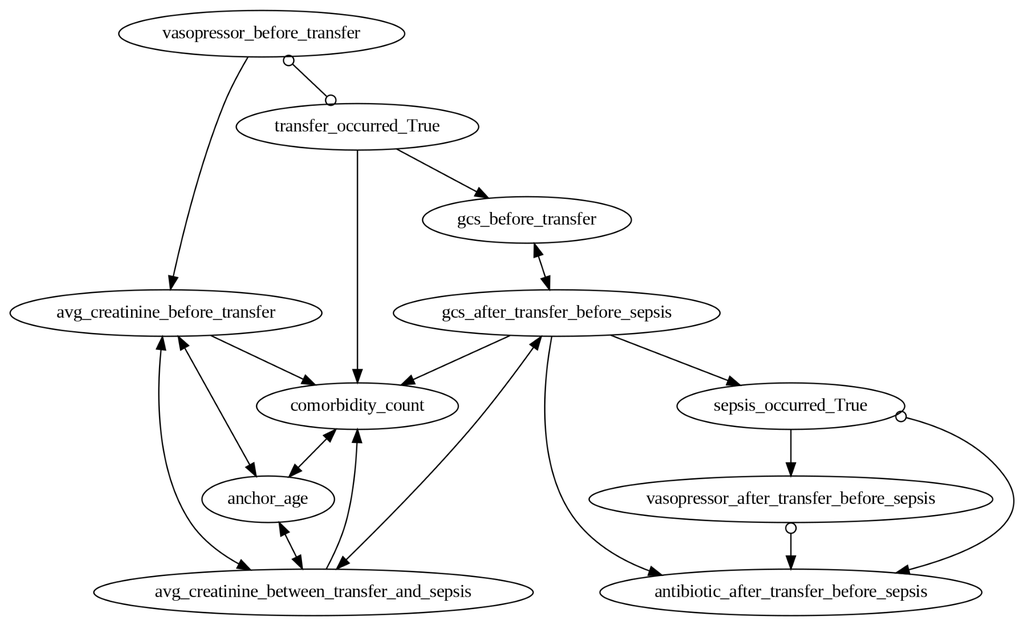

The directed arrows represent direct causes, while the circles could either be directed or undirected relationships. Arrows that point in both directions suggest that there is a latent common cause between the two variables. Based on the above graph, there is an indirect path from transfer to sepsis through GCS before transfer and GCS after transfer, and a longer indirect path through comorbidity count, creatinine between transfer and sepsis, and GCS after transfer. This suggests that there may be a causal relationship between ICU transfers and sepsis, however that relationship may be mediated through other variables like GCS, creatinine, or comorbidity count.

One issue with this casual graph is that it violates the temporal alignment assumption–that arrows in the constructed graph need to correspond to the order events occur in time. This is violated by the directed arrow from the transfer variable to GCS before transfer, which is temporally impossible. We attempted to implement temporal constraints through including background knowledge, disallowing directed edges between variables that are not possible, however background knowledge constraints failed due to node naming mismatches, resolved via post-processing to remove edges like transfer_occurred_True → gcs_before_transfer. The resulting causal graph is as follows:

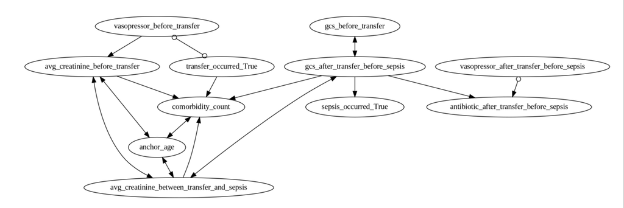

This causal graph still has the indirect path from transfer to sepsis through comorbidity count, age, creatinine after transfer, and GCS after transfer. These findings inform the selection of covariates for causal effect estimation.

### Estimating the Causal Effect

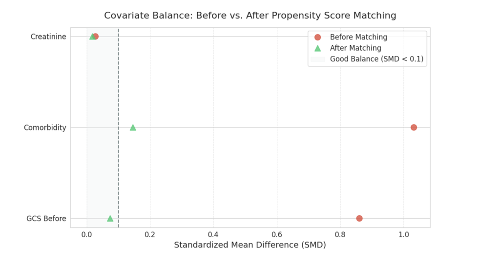

The above Love Plot demonstrates how similar the covariates in the treatment compared to the control group are before the propensity score matching (red circles), and after (green triangles). Good covariate balance is typically indicated by a standardized covariate mean difference (SMD) of less than 0.1. Although comorbidity has an SMD slightly above 0.1 after matching, its SMD was reduced from 1.03 to 0.145 suggesting that propensity score matching improved covariate balance in the data.

## Conclusions

This study aimed to investigate the causal relationship between inter-unit ICU transfers and sepsis outcomes using causal discovery and inference techniques. The FCI algorithm revealed no direct causal relationship between ICU transfers and sepsis, but did identify several potential mediators and confounders including Glasgow Coma Scale, creatinine, and comorbidities.

Causal effect estimation using propensity score matching, IPW, and doubly-robust estimation resulted in small but statistically significant negative effect of ICU transfer on sepsis. However, this is counterintuitive and may potentially be biased by the exclusion of potential confounders. Also, the possibility of mediating variables indicated in the causal graph from FCI emphasizes the need for further research.

A major limitation of this study was that not all potential confounding variables were measured and available in the dataset. Future studies could try to incorporate additional clinical variables and use more advanced inference methods to better understand the causal pathways linking ICU transfers to sepsis.

A second limitation was the computational constraints from the inefficiency of KCI, resulting in the application of causal discovery only to a limited subset of variables instead of all relevant variables. Different independence test implementations (e.g. FastKCI) or further optimization could uncover a more thorough, accurate causal graph.

A third limitation was the challenge of temporal alignment. The causal discovery methods used orient edges based on conditional independence tests, but these tests do not by default have knowledge of the temporal order of variables, resulting in nonsensical directed edges. Improved implementation of background knowledge or further preprocessing could help resolve this.

These findings highlight the complexity of ICU transfer effects on sepsis and underscore the need for refined causal models to inform transfer policies and improve patient outcomes.

## Bibliography

Causal Discovery example — DoWhy documentation. (n.d.). https://www.pywhy.org/dowhy/v0.11/example_notebooks/dowhy_causal_discovery_example.html

Johnson, A., Bulgarelli, L., Pollard, T., Gow, B., Moody, B., Horng, S., Celi, L. A., & Mark, R. (2024). MIMIC-IV (version 3.1). *PhysioNet*. https://doi.org/10.13026/kpb9-mt58.

Johnson, A.E.W., Bulgarelli, L., Shen, L. et al. MIMIC-IV, a freely accessible electronic health record dataset. Sci Data 10, 1 (2023). https://doi.org/10.1038/s41597-022-01899-x

Liu, H., Hou, S., & Tian, X. (2023). Risk Factors of Sepsis Associated Acute Kidney Injury in Patients with Sepsis: A Meta-Analysis. Intensive Care Research. https://doi.org/10.1007/s44231-023-00034-7

MIMIC-IV v3.1. (2024, October 11). https://physionet.org/content/mimiciv/3.1/

Mit-Lcp. (n.d.). mimic-code/mimic-iii/concepts/severityscores/sofa.sql at main · MIT-LCP/mimic-code. GitHub. https://github.com/MIT-LCP/mimic-code/blob/main/mimic-iii/concepts/severityscores/sofa.sql

Moor, M., Rieck, B., Horn, M., Jutzeler, C. R., & Borgwardt, K. (2021). Early prediction of sepsis in the ICU using Machine Learning: A systematic review. Frontiers in Medicine, 8. https://doi.org/10.3389/fmed.2021.607952

Omar, S. A., Alshraideh, J. A., Oweidat, I., Qadire, M. A., Khalaf, A., Sumaqa, Y. A., Al-Mugheed, K., Alabdullah, A. a. S., & Abdelaliem, S. M. F. (2024). Mortality of patients with sepsis in intensive care units at tertiary hospitals in Jordan: Prospective cohort study. Medicine, 103(43), e40169. https://doi.org/10.1097/md.0000000000040169

Parenmark, F., & Walther, S. M. (2022). Intensive care unit to unit capacity transfers are associated with increased mortality: an observational cohort study on patient transfers in the Swedish Intensive Care Register. Annals of Intensive Care, 12(1). https://doi.org/10.1186/s13613-022-01003-x

Py-Why. (n.d.). Understanding the FCI outputs (graph vs. printed edges) · Issue #180 · py-why/causal-learn. GitHub. https://github.com/py-why/causal-learn/issues/180

Sakr, Y., Jaschinski, U., Wittebole, X., Szakmany, T., Lipman, J., Ñamendys-Silva, S. A., Martin-Loeches, I., Leone, M., Lupu, M., & Vincent, J. (2018). Sepsis in Intensive Care Unit Patients: Worldwide Data From the Intensive Care over Nations Audit. Open Forum Infectious Diseases, 5(12). https://doi.org/10.1093/ofid/ofy313

Shen, X., Ma, S., Vemuri, P., Simon, G., Weiner, M. W., Aisen, P., Petersen, R., Jack, C. R., Saykin, A. J., Jagust, W., Trojanowki, J. Q., Toga, A. W., Beckett, L., Green, R. C., Morris, J., Shaw, L. M., Khachaturian, Z., Sorensen, G., Carrillo, M., . . . Fargher, K. (2020). Challenges and Opportunities with Causal Discovery Algorithms: Application to Alzheimer’s Pathophysiology. Scientific Reports, 10(1). https://doi.org/10.1038/s41598-020-59669-x

Singer, M., Deutschman, C. S., Seymour, C. W., Shankar-Hari, M., Annane, D., Bauer, M., Bellomo, R., Bernard, G. R., Chiche, J., Coopersmith, C. M., Hotchkiss, R. S., Levy, M. M., Marshall, J. C., Martin, G. S., Opal, S. M., Rubenfeld, G. D., Van Der Poll, T., Vincent, J., & Angus, D. C. (2016). The third international consensus definitions for sepsis and septic shock (SEpsis-3). JAMA, 315(8), 801. https://doi.org/10.1001/jama.2016.0287

Welcome to causallib’s documentation! — causallib 0.9.6 documentation. (n.d.). https://causallib.readthedocs.io/en/latest/

Zhang, K., Peters, J., Janzing, D., & Schoelkopf, B. (2012, February 14). Kernel-based conditional independence test and application in causal discovery. arXiv.org. https://arxiv.org/abs/1202.3775

Zhou, J., Luo, X., Chen, G., Li, H., Xu, M., Liu, S., Yang, Y., Shi, G., Zhou, J., & Zhang, L. (2022). Incidence, risk factors and outcomes of sepsis in critically ill post-craniotomy patients: a Single-Center Prospective Cohort study. Frontiers in Public Health, 10. https://doi.org/10.3389/fpubh.2022.895991